# Birth Rates in the US from 1995 to 2017 : An Exploratory Analysis

Responses Submitted for Precision-Analytics Entry Exam

Corey Pembleton https://data-break.netlify.com (Precision-Analytics)https://www.precision-analytics.ca/  
2019-06-24

# 1. Load the Data

```r
library(tidyverse)
library(naniar)
library(kableExtra)
library(DataExplorer)
```

```r
paths <- paste0("fertility-challenge/", list.files("fertility-challenge/", pattern = "*.txt"))
Births <- map_dfr(paths, ~ read_tsv(.x))
```

Looks like on the data load some parsing errors occured in one of the columns where only one of the 10 columns is used (Notes column) - will review this later.

# 2. Exploratory Data Analysis

Can get to know the data a few ways, first, a summary of what it looks like w/ base R:

```r
summary(Births)
```

```
    Notes              State            State Code
 Length:1473        Length:1473        Length:1473
 Class :character   Class :character   Class :character
 Mode  :character   Mode  :character   Mode  :character




      Year        Year Code        Births         Total Population
 Min.   :1995   Min.   :1995   Min.   :    5655   Min.   :5.035e+05
 1st Qu.:2000   1st Qu.:2000   1st Qu.:   25383   1st Qu.:1.855e+06
 Median :2006   Median :2006   Median :   63201   Median :4.758e+06
 Mean   :2006   Mean   :2006   Mean   :  208997   Mean   :1.598e+07
 3rd Qu.:2012   3rd Qu.:2012   3rd Qu.:  119847   3rd Qu.:9.550e+06
 Max.   :2017   Max.   :2017   Max.   :44300538   Max.   :3.452e+09
 NA's   :300    NA's   :300    NA's   :144        NA's   :604
   Birth Rate    Female Population   Fertility Rate
 Min.   : 9.02   Min.   :   101425   Min.   :49.67
 1st Qu.:12.06   1st Qu.:   358575   1st Qu.:60.69
 Median :13.00   Median :   959756   Median :64.61
 Mean   :13.14   Mean   :  3245987   Mean   :65.20
 3rd Qu.:14.08   3rd Qu.:  1938741   3rd Qu.:69.54
 Max.   :21.22   Max.   :692136267   Max.   :95.67
 NA's   :604     NA's   :604         NA's   :604
```

And to visualize this by type and oberservation, the `DataExplorer` package can help:

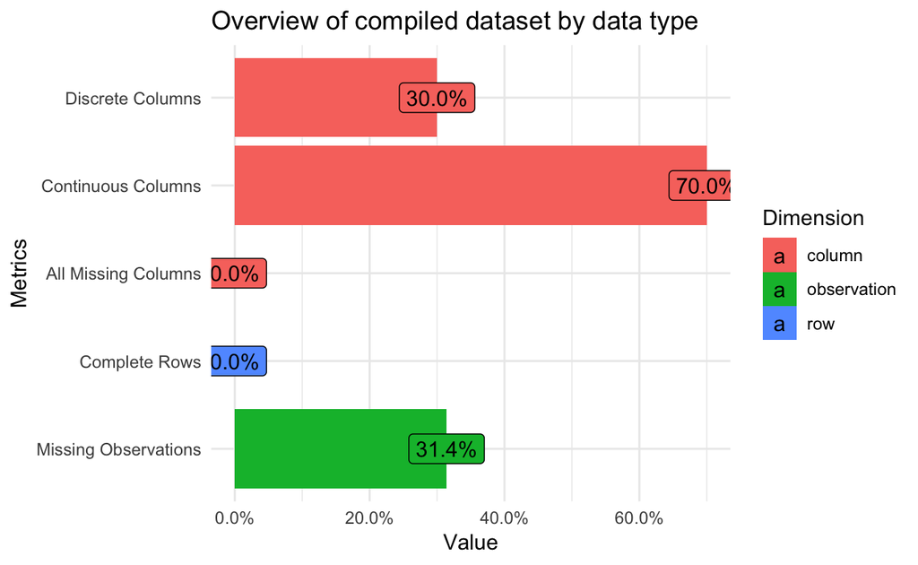

This shows something of a mixed picture - with not a single column or row that is complete, looks mostly due to that Notes column, but maybe other data is missing. Looking at the missing data by variable shows some patterns worth exploring further:

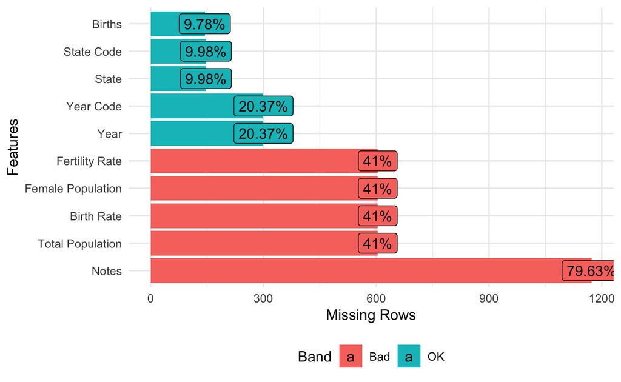

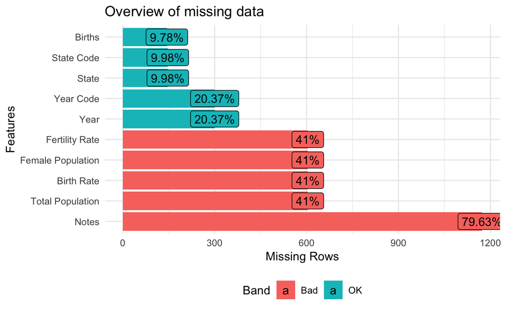

The Notes variable which looks like a data dictionary column added to the bottom of each .txt file that was loaded:

| Notes | n |
| --- | --- |
| NA | 1173 |
| Total | 156 |
| --- | 15 |
| 1. Each birth record represents one living baby. | 3 |
| Caveats: | 3 |
| Help: See http://wonder.cdc.gov/wonder/help/Natality.html for more information. | 3 |
| Query Parameters: | 3 |
| Show Suppressed: False | 3 |
| Show Totals: True | 3 |
| Show Zero Values: False | 3 |

[output cut: 84 more lines]

Looking at Notes closer: it contains `NA` values, Total values, and descriptive values. The Total row look like sum values added to the end of each state, per file:

```r
Births %>% filter(Notes == "Total") %>%
  select(State, Year, Notes, Births, everything()) %>%
  rmarkdown::paged_table(options = list(rows.print = 10))
```

| State | Year | Notes | Births | State Code | Year Code | Total Population | Birth Rate | Female Population | Fertility Rate |
| --- | --- | --- | --- | --- | --- | --- | --- | --- | --- |
| Alabama | NA | Total | 488647 | 01 | NA | NA | NA | NA | NA |
| Alaska | NA | Total | 80019 | 02 | NA | NA | NA | NA | NA |
| Arizona | NA | Total | 641579 | 04 | NA | NA | NA | NA | NA |
| Arkansas | NA | Total | 293848 | 05 | NA | NA | NA | NA | NA |
| California | NA | Total | 4245562 | 06 | NA | NA | NA | NA | NA |
| Colorado | NA | Total | 489279 | 08 | NA | NA | NA | NA | NA |
| Connecticut | NA | Total | 346717 | 09 | NA | NA | NA | NA | NA |
| Delaware | NA | Total | 84818 | 10 | NA | NA | NA | NA | NA |
| District of Columbia | NA | Total | 63328 | 11 | NA | NA | NA | NA | NA |
| Florida | NA | Total | 1578655 | 12 | NA | NA | NA | NA | NA |

[output cut: 146 more lines]

```r
Births <- Births %>% filter(is.na(Notes)) %>% select(-Notes)
```

With notes removed, can get a more accurate view of missing data. The entire first file (1995 - 2002) doesn’t have the same data as the other files, something to keep in mind for any future analysis.

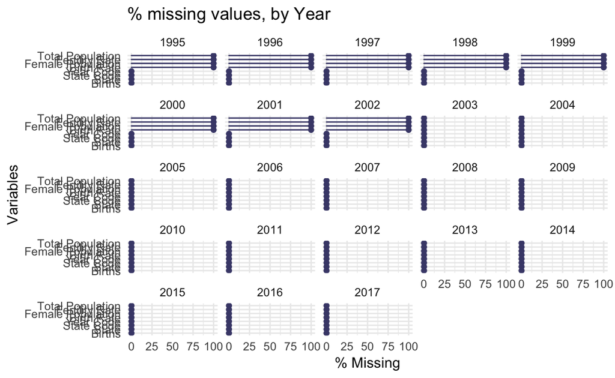

```r
Births %>%
  group_by(Year) %>%
  naniar::gg_miss_var(show_pct = TRUE, facet = Year) +
  ggtitle("% missing values, by Year")
```

`naniar::gg_miss_upset()` is a good way to see what the relationship between missing values is:

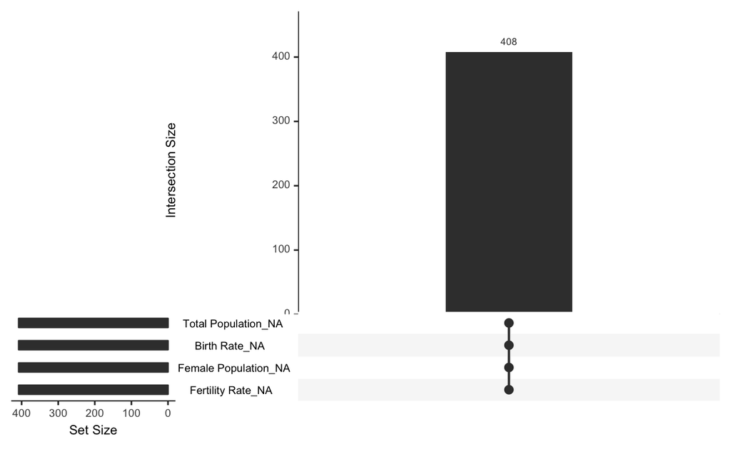

```r
Births %>%
  naniar::gg_miss_upset()
```

It appears that the only missing values are from those years without the variables listed in the figure above, can do a quick check of that to verify:

```r
Births %>%
  filter(Year < 2003) %>%
  nrow()
```

```
[1] 408
```

Looks good (for the purposes of this exercise) - time to get on with some more fun things than data cleaning!

## 3. Time Series Plot

The time series plot shows a peak in births around 2007, with a trend towards the birth figures of the late 1990’s returning in the mid 2010’s.

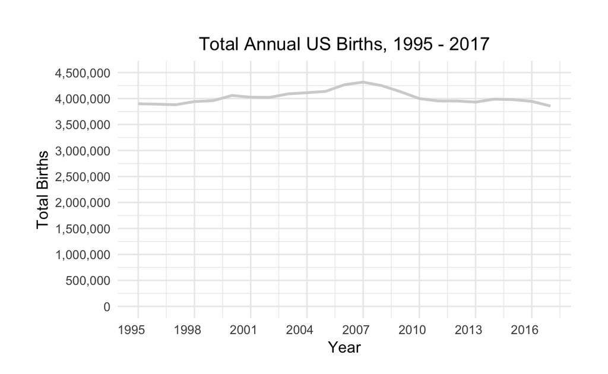

Looking at each state, we see that the golden state has the highest count of births (but tied for last in basketball championship titles in 2019).

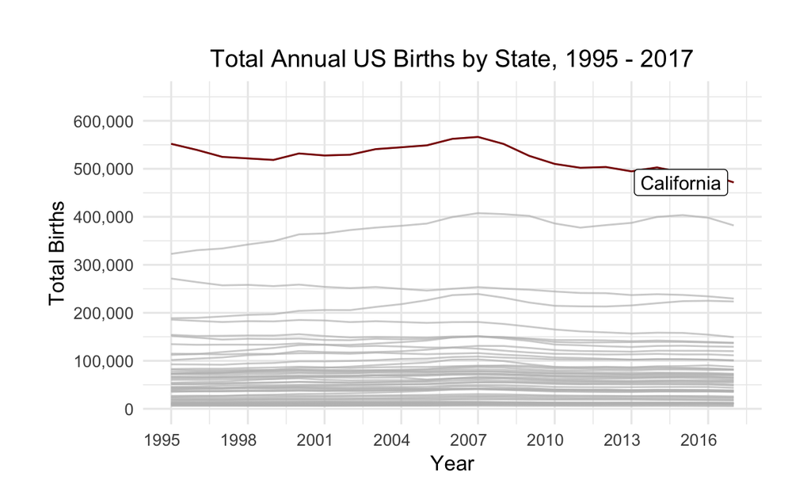

## 4. Linear Regression: BR impact by year & state?

Using linear regression, we can estimate how state and year influence birth rates over time:

Looking first at `Year` alone:

```r
#first filter the data before 2002 that doesn't have BR values
Births_2002_over <- Births %>% filter(Year >= 2003)

#center the Year variable
Births_2002_over <- Births_2002_over %>% mutate(Year_New = Year-2003)

#run initial model
model1 <- lm(data = Births_2002_over, formula = `Birth Rate` ~ Year_New)

tmp <- capture.output(summary(model1))

cat(tmp[c(3:4, 9:13, 16:17)], sep='\n')
```

```
lm(formula = `Birth Rate` ~ Year_New, data = Births_2002_over)

Coefficients:
            Estimate Std. Error t value Pr(>|t|)
(Intercept)  14.2269     0.1135  125.33   <2e-16 ***
Year_New     -0.1596     0.0138  -11.57   <2e-16 ***
---
Residual standard error: 1.649 on 763 degrees of freedom
Multiple R-squared:  0.1492,    Adjusted R-squared:  0.1481
```

Which can be graphically represented as:

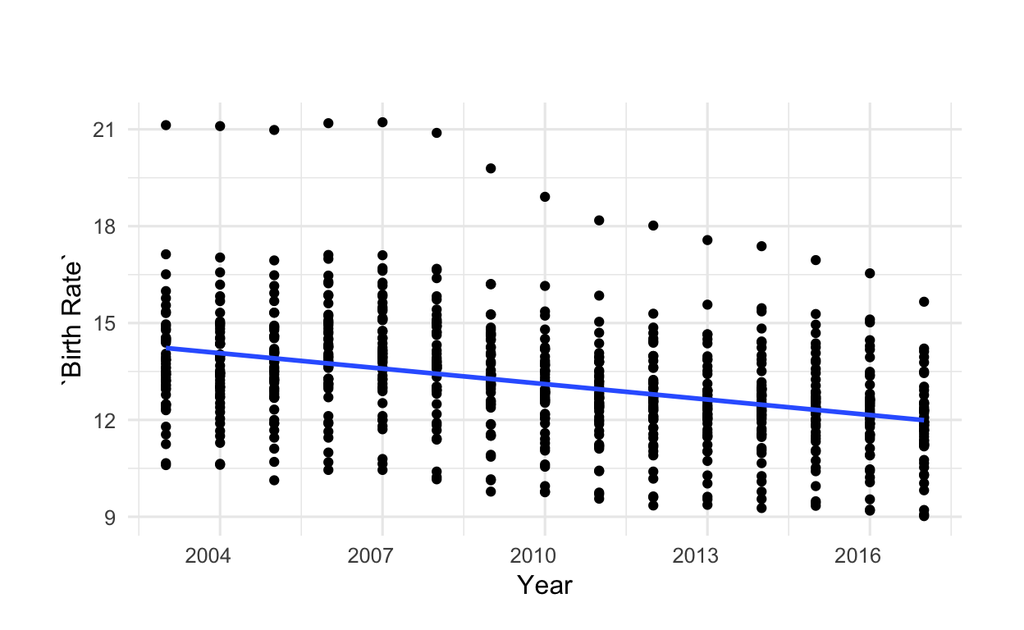

```r
ggplot(Births_2002_over, aes(x = Year, y = `Birth Rate`)) +
  geom_point() +
  stat_smooth(method = "lm", formula = y~x, se=FALSE, linetype = 1) +
  scale_x_continuous(breaks = seq(1995, 2017, 3))+
  theme_minimal(12) +
  theme(legend.position = "none",
        axis.text.x = element_text(hjust = .75),
        plot.title = element_text(size=14, hjust = 0.5),
        plot.caption = element_text(size = 12, hjust = 1),
        axis.text.y = element_text(hjust = 1),
        plot.margin = unit(c(1,1,0.5,1), "cm")) +
  ggtitle("")
```

## 4.1 Interpretation

This linear model tells me that in 2003 there was a birth rate of 14.2, with an estimated decrease of .16 every year. The year variable is [centered](http://www.med.mcgill.ca/epidemiology/joseph/courses/EPIB-621/centered_var.pdf) around the actual years (rather than year 0), which makes the interpretation easier to interpret by essentially shifting the y-axis to the years of interest (post 2003).

### Year and State

```r
model2 <- lm(data = Births_2002_over, formula = `Birth Rate` ~ Year_New + State)

tmp2 <- capture.output(summary(model2))

cat(tmp2[c(3:4, 9:68)], sep='\n')
```

```
lm(formula = `Birth Rate` ~ Year_New + State, data = Births_2002_over)

Coefficients:
                           Estimate Std. Error t value Pr(>|t|)
(Intercept)               13.902137   0.148453  93.647  < 2e-16 ***
Year_New                  -0.159639   0.004692 -34.022  < 2e-16 ***
StateAlaska                2.889333   0.204742  14.112  < 2e-16 ***
StateArizona               1.614000   0.204742   7.883 1.20e-14 ***
StateArkansas              0.712667   0.204742   3.481 0.000530 ***
StateCalifornia            1.190667   0.204742   5.815 9.13e-09 ***
StateColorado              0.669333   0.204742   3.269 0.001130 **
StateConnecticut          -1.894667   0.204742  -9.254  < 2e-16 ***
StateDelaware             -0.050667   0.204742  -0.247 0.804619
StateDistrict of Columbia  1.828667   0.204742   8.932  < 2e-16 ***
StateFlorida              -1.021333   0.204742  -4.988 7.66e-07 ***
StateGeorgia               1.494667   0.204742   7.300 7.69e-13 ***
StateHawaii                0.956667   0.204742   4.673 3.56e-06 ***
StateIdaho                 2.168000   0.204742  10.589  < 2e-16 ***
StateIllinois              0.358667   0.204742   1.752 0.080238 .
StateIndiana               0.456667   0.204742   2.230 0.026028 *
StateIowa                  0.118000   0.204742   0.576 0.564570
StateKansas                1.283333   0.204742   6.268 6.33e-10 ***
StateKentucky              0.292000   0.204742   1.426 0.154252
StateLouisiana             1.210000   0.204742   5.910 5.30e-09 ***
StateMaine                -2.788000   0.204742 -13.617  < 2e-16 ***
StateMaryland              0.098667   0.204742   0.482 0.630019
StateMassachusetts        -1.437333   0.204742  -7.020 5.17e-12 ***
StateMichigan             -0.816667   0.204742  -3.989 7.33e-05 ***
StateMinnesota             0.476667   0.204742   2.328 0.020184 *
StateMississippi           1.174667   0.204742   5.737 1.42e-08 ***
StateMissouri              0.202667   0.204742   0.990 0.322576
StateMontana              -0.492667   0.204742  -2.406 0.016369 *
StateNebraska              1.659333   0.204742   8.105 2.30e-15 ***
StateNevada                1.002000   0.204742   4.894 1.22e-06 ***
StateNew Hampshire        -2.714000   0.204742 -13.256  < 2e-16 ***
StateNew Jersey           -0.416000   0.204742  -2.032 0.042541 *
StateNew Mexico            0.876000   0.204742   4.279 2.14e-05 ***
StateNew York             -0.233333   0.204742  -1.140 0.254816
StateNorth Carolina        0.271333   0.204742   1.325 0.185514
StateNorth Dakota          1.096000   0.204742   5.353 1.17e-07 ***
StateOhio                 -0.356000   0.204742  -1.739 0.082506 .
StateOklahoma              1.392000   0.204742   6.799 2.23e-11 ***
StateOregon               -0.688000   0.204742  -3.360 0.000820 ***
StatePennsylvania         -1.386000   0.204742  -6.770 2.70e-11 ***
StateRhode Island         -1.824667   0.204742  -8.912  < 2e-16 ***
StateSouth Carolina       -0.018667   0.204742  -0.091 0.927382
StateSouth Dakota          1.838667   0.204742   8.980  < 2e-16 ***
StateTennessee             0.148667   0.204742   0.726 0.468005
StateTexas                 2.876000   0.204742  14.047  < 2e-16 ***
StateUtah                  6.249333   0.204742  30.523  < 2e-16 ***
StateVermont              -2.880667   0.204742 -14.070  < 2e-16 ***
StateVirginia              0.260667   0.204742   1.273 0.203380
StateWashington            0.155333   0.204742   0.759 0.448295
StateWest Virginia        -1.570667   0.204742  -7.671 5.59e-14 ***
StateWisconsin            -0.595333   0.204742  -2.908 0.003754 **
StateWyoming               0.724667   0.204742   3.539 0.000427 ***
---
Signif. codes:  0 '***' 0.001 '**' 0.01 '*' 0.05 '.' 0.1 ' ' 1

Residual standard error: 0.5607 on 713 degrees of freedom
Multiple R-squared:  0.9081,    Adjusted R-squared:  0.9015
F-statistic: 138.1 on 51 and 713 DF,  p-value: < 2.2e-16
```

# 5. Diffs-in-Diffs Analysis

A differences in differences (DD) analysis can be described as an analysis where outcomes are observed for two groups during two time periods,an analysis which is widespread in use although has been criticized for showing inconsistencies in resultant standard errors[^1]. This criticism should be considered when interpreting the results of a DD analysis, but nonetheless does not mean the analysis should not be completed.

## 5.1 Difference in Differences Case: Effect of Abstinance Policy in Three U.S. States

I will use a a diffs-in-diffs analysis to create a plot on an abstinence only policy that was implemented in 2008 in three states: New Jersey, Georgia and Texas. The plot examines whether the parallel trends assumptions are met in the treated states versus the control states.

This will be completed using only states that have population denominators.

```r
Births_pop <- Births %>%
  filter(`Total Population` > 0)

Births_treated <- Births_pop %>%
  mutate(
    states_treated = case_when(
      State %in% c("New Jersey", "Georgia", "Texas") ~ 1,
      TRUE ~ 0
      ),
    post2008 = Year >= 2008
      )
```

First, the data should include only that with population data, and include an identifer differentiating the states with and without the policy, stored as Births_treated.

When examining to see whether or not the parallel trends assumption is broken, a visual inspection works:

> “Although there is no statistical test for this assumption, visual inspection is useful when you have observations over many time points.” [^2]

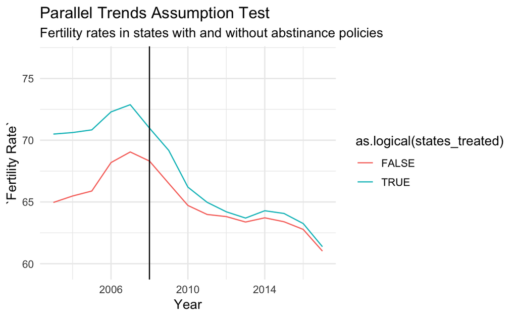

```r
ggplot(Births_treated, aes(Year, `Fertility Rate`, color = as.logical(states_treated))) +
  stat_summary(geom = "line") +
  geom_vline(xintercept = 2008) +
  theme_minimal(12) +
  ggtitle("Parallel Trends Assumption Test",
          subtitle = "Fertility rates in states with and without abstinance policies")
```

## 5.2 Estimating the impact of the 2008 policy on fertility rates between states

DD is “usually implemented as an interaction term between time and treatment variables in a regression model” [^3]; hence looking at the relationship between the treated states and the time of the intervention, the interaction term can be gathered as:

```r
model = lm(`Fertility Rate` ~ states_treated*post2008, data = Births_treated)
summary(model)
```

```
Call:
lm(formula = `Fertility Rate` ~ states_treated * post2008, data = Births_treated)

Residuals:
    Min      1Q  Median      3Q     Max
-16.485  -4.214  -0.675   4.206  30.636

Coefficients:
                            Estimate Std. Error t value Pr(>|t|)
(Intercept)                  66.7150     0.4740 140.737  < 2e-16 ***
states_treated                4.7130     1.9545   2.411   0.0161 *
post2008TRUE                 -2.5511     0.5806  -4.394 1.27e-05 ***
states_treated:post2008TRUE  -3.6536     2.3938  -1.526   0.1274
---
Signif. codes:  0 '***' 0.001 '**' 0.01 '*' 0.05 '.' 0.1 ' ' 1

Residual standard error: 7.344 on 761 degrees of freedom
Multiple R-squared:  0.03856,   Adjusted R-squared:  0.03477
F-statistic: 10.17 on 3 and 761 DF,  p-value: 1.419e-06
```

```r
model2 = lm(`Fertility Rate` ~ Year + states_treated + states_treated*post2008, data = Births_treated)

summary(model2)
```

```
Call:
lm(formula = `Fertility Rate` ~ Year + states_treated + states_treated *
    post2008, data = Births_treated)

Residuals:
     Min       1Q   Median       3Q      Max
-16.4850  -4.2282  -0.5423   3.8483  29.8284

Coefficients:
                            Estimate Std. Error t value Pr(>|t|)
(Intercept)                 942.3018   212.1547   4.442 1.03e-05 ***
Year                         -0.4367     0.1058  -4.127 4.08e-05 ***
states_treated                4.7130     1.9342   2.437   0.0151 *
post2008TRUE                  0.7242     0.9797   0.739   0.4600
states_treated:post2008TRUE  -3.6536     2.3690  -1.542   0.1234
---
Signif. codes:  0 '***' 0.001 '**' 0.01 '*' 0.05 '.' 0.1 ' ' 1

Residual standard error: 7.268 on 760 degrees of freedom
Multiple R-squared:  0.05963,   Adjusted R-squared:  0.05468
F-statistic: 12.05 on 4 and 760 DF,  p-value: 1.687e-09
```

[^1]: https://economics.mit.edu/files/750
[^2]: https://www.mailman.columbia.edu/research/population-health-methods/difference-difference-estimation
[^3]: https://www.mailman.columbia.edu/research/population-health-methods/difference-difference-estimation